# Segmentation

Please run the cell the in order listed in the notebook.

The rmd is meant to be used as an introduction to ML segmentation based on document": **202002_ML training Segmentation.ppt**

# Library

Loading the required libraries, setting override and seed.

# Data Loading

```r
# loading the data
# note that this assumes that the whole github repo is downloaded with the original structure
oncology.profile.dt<-fread(file.path("Data", "OncologyProfile.csv"))

# printing here, although this isn't very friendly for html
head(oncology.profile.dt)
```

```
##    completeObs.SEIN completeObs.POUMON completeObs.GYNECO completeObs.PROSTATE
## 1:                0                  0                  0                   20
## 2:               80                  0                 15                    0
## 3:               31                  8                 12                   10
## 4:               20                 12                  5                   20
## 5:                0                  0                  0                    0
## 6:               15                 11                 11                   11
##    completeObs.VESSIE completeObs.REIN completeObs.DIGESTIF completeObs.FOIE
## 1:                 10               10                   60                0
## 2:                  0                0                    0                0
## 3:                  1                1                    8                0
## 4:                  6                6                   25                0
## 5:                  0                0                    0                0
## 6:                  4                4                   15                4
##    completeObs.THYROIDE completeObs.MELANOME completeObs.TETE.ET.COU..ORL
## 1:                    0                    0                            0
## 2:                    0                    0                            0
## 3:                    0                    1                            8
## 4:                    0                    0                            6
## 5:                    0                    5                           60
## 6:                    0                    0                            0
##    completeObs.AUTRES
## 1:                  0
## 2:                  5
## 3:                  0
## 4:                  0
## 5:                 35
## 6:                  0
```

```r
# stargazer::stargazer(head(oncology.profile.dt), type = "html",
#  title = "Table with patient oncology profile")
```

# PCA - Dimensional Reduction

> The FactoMineR package provided most of the functionality required for the PCA computation (such as the numerical calculation and also plotting) here for PCA.

**Definition**: Deconstructing the data into lesser dimension (for instance going from a 12-variable description to a 2D description) for synthetic comprehension and visualization.

**In Practice** - It finds the Principal Components of data, going from a N-dimensional description (N can be quite large) to a smaller dimension world that is easier to comprehend - It assumes that a large variance in data offers more information, and vice versa - The data is thus deconstructable through orthogonal-linear composition of the original dimension

**Logic**

1. Choose active variables
2. Rescale (or not) the variables
3. Perform PCA
4. Choose the number of dimensions to interpret
5. Analyze jointly the cloud of individuals and the cloud of variables
6. Use indicators to enrich interpretation
7. Go back to raw data for interpretation

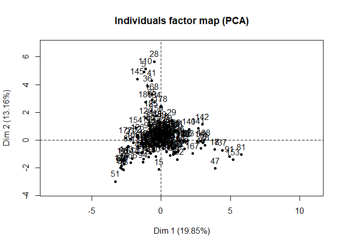

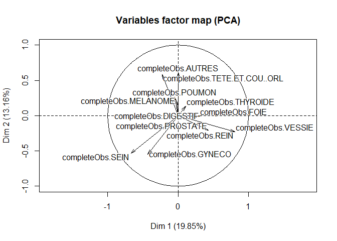

```r
# This would create the approprate graph and factor plot
# note that this is only partial of the imputed data

result.pca<-oncology.profile.dt%>%
  PCA(graph=TRUE)
```

**Linear composition for the Dim 1 and Dim 2**

The dim 1 and dim 2 of all the records can be acquired by the simple linear composition of the following values (eigenvectors). It is through such values that we acquire the individual factor map (PCA) depicted above for all records.

In essence, we have translated the data into 2D, by rotating to axes that comprise most of the data variations.

```r
data.frame(result.pca$var$coord)[1:2]
```

```
##                                     Dim.1        Dim.2
## completeObs.SEIN             -0.669445510 -0.532397497
## completeObs.POUMON           -0.050541286  0.266260775
## completeObs.GYNECO           -0.431773893 -0.550638808
## completeObs.PROSTATE          0.431805165 -0.206524603
## completeObs.VESSIE            0.807663544 -0.227232102
## completeObs.REIN              0.808481939 -0.226517708
## completeObs.DIGESTIF          0.311786417 -0.006406552
## completeObs.FOIE              0.302143750 -0.009099300
## completeObs.THYROIDE          0.106894891  0.136146237
## completeObs.MELANOME         -0.017924685  0.207326716
## completeObs.TETE.ET.COU..ORL -0.227654439  0.584504669
## completeObs.AUTRES            0.003455631  0.610690416
```

# Hierarchy clustering - Clustering

In python sklearn world, this is also known as Agglomerative Clustering (**sklearn.cluster.AgglomerativeClustering**). It is more well-known as the **hclust** function from R **stats** library. In this case, we will be using a higher level library - **FactoMineR** (which provides additional plotting & anaylsis functionalities)

**Definition**: Recursively merges the pair of clusters that minimally increases a given linkage distance.

**Methods**:

- It starts by treating each observation as a separate cluster
- Then, it repeatedly executes the following two steps (until all the clusters are merged together)
  1. Identify the two clusters that are closest together
  2. Merge the two most similar clusters
- Finally, decide where to make the cut in the hierarchical clusters to define a nb. of segments

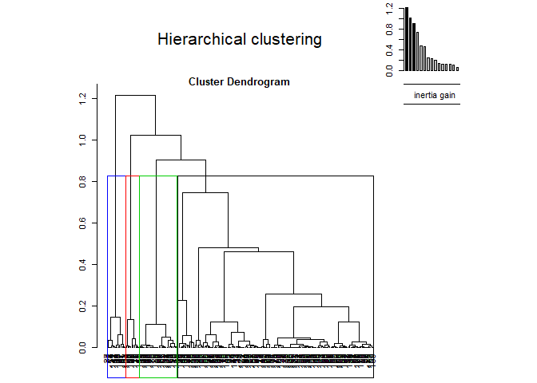

```r
# Clustering, auto nb of clusters:
hc <- HCPC(result.pca, nb.clust=-1,graph=FALSE, order=FALSE)
plot(hc, choice="tree")
```

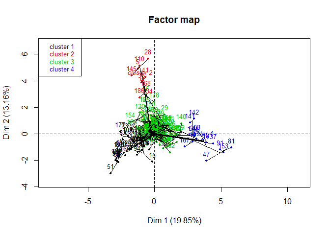

```r
plot(hc, choice="map")
```

In the dendrogram plot of clustering, the horizontal units are individual instances, while the vertical axis represents a proxy of linkage distance (distance between clusters). The number of clusters can be set by modifying at which point we would cut off the dendrogram.

There are various ways to proceed here, one could attempt to explain the individual factor components of Dim 1 and Dim 2, then use the above plots to illustrate the meaning behind Dim 1 and Dim 2. An alternative method would be to take the results of all these dimensional reduction and clustering onto the raw data.

# Hierarchy clustering - Clustering with specific number of segments

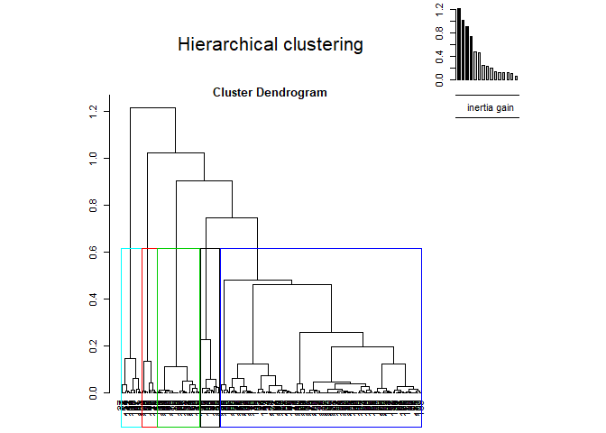

```r
# Clustering,  with mininum suggestion of 5 clusters.
# With rstudio, you can simply highlight the functions and hit F1 on your keyboard, the documentation for the corresponding function would then be shown on your right ( along with the options, methods, etc)
hc <- HCPC(result.pca, nb.clust=-1,graph=FALSE, order=FALSE, min=5)
plot(hc, choice="tree")
```

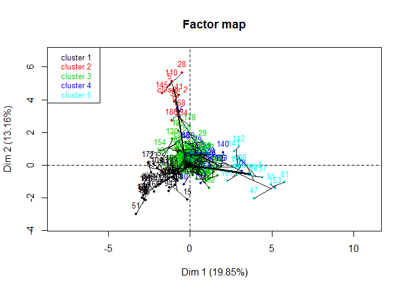

```r
plot(hc, choice="map")
```

# Hierarchy clustering - Clustering with different nb. of clusters, metrics and methods

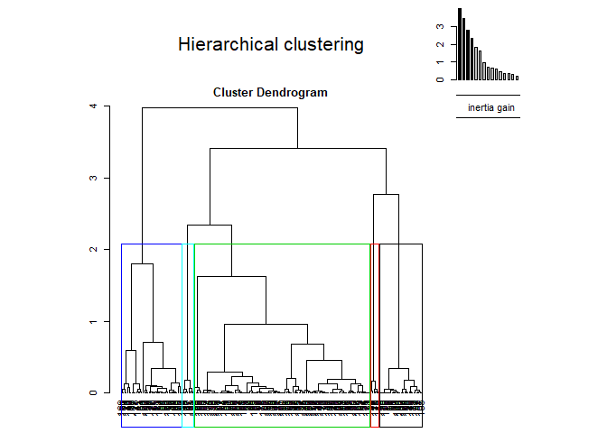

```r
# Clustering with suggestion of 5+ clusters, metrics as manhattan, and distance calculation as ward:
hc <- HCPC(result.pca, nb.clust=-1,graph=FALSE, order=FALSE, min=5, method="ward", metric="manhattan")
plot(hc, choice="tree")
```

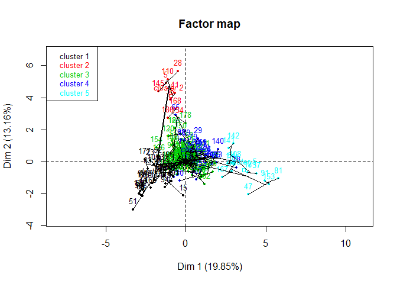

```r
plot(hc, choice="map")
```

# Output

Code chunk for csv output with the result from the segmentation.

```r
# assigning the clusters onto the raw data frame
oncology.profile.dt$cluster <-hc$data.clust$clust

# writing the results onto a local file
fwrite(oncology.profile.dt, file.path("Output", "OncologyProfileCluster.csv"))
```

# Mathematics

## PCA

PCA is an analysis method that can be done with numerous methods. One of the more intuitive methods would be through eigen-decomposition. The whole process of obtaining principle components from a raw dataset can be simplified in 4 steps:

- Compute the covariance matrix of the whole dataset.
- Compute eigenvectors and the corresponding eigenvalues.
- Sort the eigenvectors by decreasing eigenvalues and choose k eigenvectors with the largest eigenvalues to form a d × k dimensional matrix W.
- Use this d × k eigenvector matrix to transform the samples onto the new subspace.

> This is not the only way, similar linear decomposition of the data can be done by singular value decomposition (SVD), which is perhaps more simple numerically (for the mathematically inclined).

### Covariance

**Disclaimer**: Generally, it is important that the data is scaled (normalised) beforehand. Otherwise, it will be based on correlation (which is the intention for the patient profile here).

**Definition**: Covariance is the measure of the extent to which corresponding elements from two sets of ordered data move in the same direction. The formula is shown below denoted by cov(x,y) as the covariance of x and y.

$$cov(x,y) = \frac{\sum (x_i-\hat{x})(y_i - \hat{y})}{N}$$

Hence, for a data with 3 dimension of x, y, z variables.

$$Cov({A}) = \begin{bmatrix}
Cov(x,x) , Cov(x,y), Cov(x,z)\\
Cov(y,x) , Cov(y,y), Cov(y,z)\\
Cov(z,x) , Cov(z,y), Cov(z,z)
\end{bmatrix}$$

Since the covariance of a variable with itself is its variance (Cov(a,a)=Var(a)), in the diagonal (top left to bottom right), we actually have the variances of each initial variable. Since the covariance is commutative (Cov(a,b)=Cov(b,a)), the entries of the covariance matrix are symmetric with respect to the main diagonal, which means that the upper and the lower triangular portions are equal.

The relationship can thus be simplified to:

$$Cov({A}) = \begin{bmatrix}
Var(x) , Cov(x,y), Cov(x,z)\\
Cov(x,y) , Var(y), Cov(y,z)\\
Cov(x,z) , Cov(y,z), Var(z)
\end{bmatrix}$$

*What do the covariances that we have as entries of the matrix tell us about the correlations between the variables?*

It’s the sign of the covariance that matters :

-if positive, then the two variables increase or decrease together (correlated) -if negative, then one increases when the other decreases (inversely correlated)

Now that we know that the covariance matrix is nothing more than a table that summarizes correlations between all possible pairs of variables, let’s move on to the next step.

### Eigenvectors

Eigenvectors and eigenvalues are the elements we need to compute from the covariance matrix in order to determine the principal components of the data. Some simple linear algebra transformations allow us to calculate them.

*Intuitively, an eigenvector is a vector whose direction remains unchanged when a linear transformation is applied to it.*

$$[Covariance Matrix]\cdot [Eigenvector] = [Eigenvalues] \cdot [Eigenvector]$$

$$A v = \lambda v$$

The eigenvalues of A are roots of the characteristic equation

$$det(A-\lambda I) = 0$$

The eigenvalues are then obtained as the solutions of the equation for $\lambda$.

### Simple Example - student scores

Let’s start with an easy example - 5 students’ scores for 3 exams: Math, English and Art.

```r
student.dt<-data.frame(student =1:5, math = c(90,60,90,60,30),english = c(60, 90,60 ,60 ,30), art = c(90,30,60,90,30))
student.dt
```

```
##   student math english art
## 1       1   90      60  90
## 2       2   60      90  30
## 3       3   90      60  60
## 4       4   60      60  90
## 5       5   30      30  30
```

From this data, the mean for the matrix $\tilde{A}$ is

$$\bar{A} = \begin{bmatrix}
66 , 60, 60
\end{bmatrix}$$

The covariance matrix of scores among the 3 variables is

```r
# data.frame(cov((student.dt[1:5])))
```

$$Cov({A}) =
\begin{bmatrix}
630 & 225 & 450\\
225 & 450 & 0\\
450& 0 & 900
\end{bmatrix}$$

For eigenvalues/vector decomposition, we would thus solve

$$det(Cov(A)-\lambda I) = 0$$

$$0 = det
\begin{pmatrix}
630-\lambda & 225 & 450 \\
225 & 450- \lambda & 0\\
450 & 0 & 900 -\lambda
\end{pmatrix}$$

# Hierarchical Clustering

**Methods** (for bottom-up approach):

It starts by treating each observation as a separate cluster.

Then, it repeatedly executes the following two steps (until all the clusters are merged):

1. Identify the two clusters that are closest together
2. Merge the two most similar clusters

Finally, decide where to cut the hierarchical clusters to define the number of segments

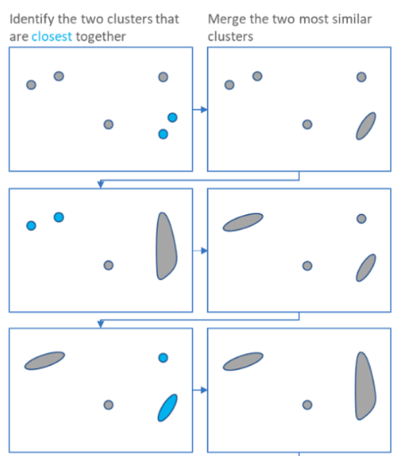

Figure (1) -Process of hclust

**Distance Options**

There are a few ways to determine how close two clusters are:

- **Complete linkage clustering**: Find the maximum possible distance between points belonging to two different clusters.
- **Single linkage clustering**: Find the minimum possible distance between points belonging to two different clusters.
- **Mean linkage clustering**: Find all possible pairwise distances for points belonging to two different clusters and then calculate the average.
- **Centroid linkage clustering**: Find the centroid of each cluster and calculate the distance between centroids of two clusters.

Complete linkage and mean linkage clustering are most frequently used.

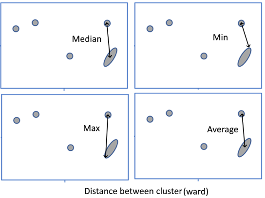

Figure (2) - hclust distance option

The method for distance calculation between points can also be chosen among a variety of options. For numerical values we use *euclidean* by default. *Manhattan* is at times use for categorical values.

# References

1. [PCA mathematical explanation](https://towardsdatascience.com/the-mathematics-behind-principal-component-analysis-fff2d7f4b643)
2. [PCA background information](https://medium.com/@aptrishu/understanding-principle-component-analysis-e32be0253ef0)
3. [Hierachy Clustering](https://www.datacamp.com/community/tutorials/hierarchical-clustering-R)

# Apendices

Below listed some fo the more popular alternative algorithm for the techniques described.

1. **Dimension reduction techniques** – such as PCA, MDS, tsne…
2. **Clustering technique** – such as hclust, kmeans, kmedoids…